# はじめてのデータ・サイエンス 課題

Last Updated: 2023-06-11

# 1 プロジェクト

他の WDI のデータで、データサイエンス。

プロジェクト1 までが課題。余裕があれば、プロジェクト２、プロジェクト3 に挑戦してください。

- プロジェクト1：`gdp = "NY.GDP.MKTP.CD"` を、GNI per capita, Atlas method (current US$): NY.GNP.PCAP.CD に置き換えてデータサイエンス（視覚化を通してデータを理解）。
  - GDP の時のコードを下につけますから、コードを確認して、国などを必要に応じて変更して、気づいたこと、わかったこと、疑問に思ったことを書いていってください。
- プロジェクト2：[World Development Indicators](https://datatopics.worldbank.org/world-development-indicators/) のサイトの下にある、Data Themes（テーマ）などから自分が調べたいテーマを選び、そのテーマから、データコードを取得して、同様の分析をしてみてください。データがあまりない場合もありますので、ある程度データが多いものを選択することをお勧めします。
- プロジェクト3：可能なら、「3 R の パッケージ WDI の活用」の内容も含めて、選択した、WDI のデータについて、調べてみましょう。

## 1.1 準備 Setup

```r
Sys.setenv(LANG = "en")
library(tidyverse)
library(WDI)
```

```r
dir.create("./data")
```

# 2 プロジェクト１

## 2.1 データ取得 Import data

GNI per capita, Atlas method (current US$): NY.GNP.PCAP.CD ですから、変数名を　`gnppcap` 名前を、`df_gnppcap` に変えてみました。他の名前でも構いません。そのときは、適宜変更していってください。

```r
df_gnppcap <- WDI(country = "all",
              indicator = c(gnppcap = "NY.GNP.PCAP.CD"),
              extra = TRUE)
```

## 2.2 データ構造の確認

```r
head(df_gnppcap)
```

|  | country | iso2c | iso3c | year | gnppcap | status | lastupdated | region | capital | longitude | latitude | income | lending |
| --- | --- | --- | --- | --- | --- | --- | --- | --- | --- | --- | --- | --- | --- |
| 1 | Afghanistan | AF | AFG | 1963 | NA |  | 2023-05-10 | South Asia | Kabul | 69.1761 | 34.5228 | Low income | IDA |
| 2 | Afghanistan | AF | AFG | 1962 | NA |  | 2023-05-10 | South Asia | Kabul | 69.1761 | 34.5228 | Low income | IDA |
| 3 | Afghanistan | AF | AFG | 1961 | NA |  | 2023-05-10 | South Asia | Kabul | 69.1761 | 34.5228 | Low income | IDA |
| 4 | Afghanistan | AF | AFG | 1960 | NA |  | 2023-05-10 | South Asia | Kabul | 69.1761 | 34.5228 | Low income | IDA |
| 5 | Afghanistan | AF | AFG | 2003 | NA |  | 2023-05-10 | South Asia | Kabul | 69.1761 | 34.5228 | Low income | IDA |
| 6 | Afghanistan | AF | AFG | 2002 | NA |  | 2023-05-10 | South Asia | Kabul | 69.1761 | 34.5228 | Low income | IDA |

```r
str(df_gnppcap)
```

```
'data.frame':   16758 obs. of  13 variables:
 $ country    : chr  "Afghanistan" "Afghanistan" "Afghanistan" "Afghanistan" ...
 $ iso2c      : chr  "AF" "AF" "AF" "AF" ...
 $ iso3c      : chr  "AFG" "AFG" "AFG" "AFG" ...
 $ year       : int  1963 1962 1961 1960 2003 2002 2001 2000 1995 1994 ...
 $ gnppcap    : num  NA NA NA NA NA NA NA NA NA NA ...
  ..- attr(*, "label")= chr "GNI per capita, Atlas method (current US$)"
 $ status     : chr  "" "" "" "" ...
 $ lastupdated: chr  "2023-05-10" "2023-05-10" "2023-05-10" "2023-05-10" ...
 $ region     : chr  "South Asia" "South Asia" "South Asia" "South Asia" ...
 $ capital    : chr  "Kabul" "Kabul" "Kabul" "Kabul" ...
 $ longitude  : chr  "69.1761" "69.1761" "69.1761" "69.1761" ...
 $ latitude   : chr  "34.5228" "34.5228" "34.5228" "34.5228" ...
 $ income     : chr  "Low income" "Low income" "Low income" "Low income" ...
 $ lending    : chr  "IDA" "IDA" "IDA" "IDA" ...
```

```r
summary(df_gnppcap)
```

```
   country             iso2c              iso3c                year
 Length:16758       Length:16758       Length:16758       Min.   :1960
 Class :character   Class :character   Class :character   1st Qu.:1975
 Mode  :character   Mode  :character   Mode  :character   Median :1991
                                                          Mean   :1991
                                                          3rd Qu.:2007
                                                          Max.   :2022

    gnppcap            status          lastupdated           region
 Min.   :    10.0   Length:16758       Length:16758       Length:16758
 1st Qu.:   586.1   Class :character   Class :character   Class :character
 Median :  1920.0   Mode  :character   Mode  :character   Mode  :character
 Mean   :  7409.2
 3rd Qu.:  7147.5
 Max.   :122470.0
 NA's   :5528
   capital           longitude           latitude            income
 Length:16758       Length:16758       Length:16758       Length:16758
 Class :character   Class :character   Class :character   Class :character
 Mode  :character   Mode  :character   Mode  :character   Mode  :character




   lending
 Length:16758
 Class :character
 Mode  :character
```

*国と、その iso2c を調べるのに役立ちます。*

```r
df_gnppcap %>% filter(region != "Aggregates") %>% distinct(country, iso2c)
```

| country | iso2c |
| --- | --- |
| Afghanistan | AF |
| Albania | AL |
| Algeria | DZ |
| American Samoa | AS |
| Andorra | AD |
| Angola | AO |
| Antigua and Barbuda | AG |
| Argentina | AR |
| Armenia | AM |
| Aruba | AW |

[output cut: 206 more lines]

*地域とその iso2c を調べるには、下のようなものが役に立ちます。*

```r
df_gnppcap %>% filter(region == "Aggregates") %>% distinct(country, iso2c)
```

| country | iso2c |
| --- | --- |
| Africa Eastern and Southern | ZH |
| Africa Western and Central | ZI |
| Arab World | 1A |
| Caribbean small states | S3 |
| Central Europe and the Baltics | B8 |
| Early-demographic dividend | V2 |
| East Asia & Pacific | Z4 |
| East Asia & Pacific (excluding high income) | 4E |
| East Asia & Pacific (IDA & IBRD countries) | T4 |
| Euro area | XC |

[output cut: 32 more lines]

### 2.2.1 メモ：あれば

## 2.3 様々な視覚化によるデータ理解

### 2.3.1 特定の国の GNI per Capita の経年変化の折線グラフ

*日本にしてありますが、他の国や地域に変えてみてください。*

```r
df_gnppcap %>% filter(country == "Japan") %>% head()
```

|  | country | iso2c | iso3c | year | gnppcap | status | lastupdated | region | capital | longitude | latitude | income | lending |
| --- | --- | --- | --- | --- | --- | --- | --- | --- | --- | --- | --- | --- | --- |
| 1 | Japan | JP | JPN | 2022 | NA |  | 2023-05-10 | East Asia & Pacific | Tokyo | 139.77 | 35.67 | High income | Not classified |
| 2 | Japan | JP | JPN | 2021 | 42650 |  | 2023-05-10 | East Asia & Pacific | Tokyo | 139.77 | 35.67 | High income | Not classified |
| 3 | Japan | JP | JPN | 2020 | 40810 |  | 2023-05-10 | East Asia & Pacific | Tokyo | 139.77 | 35.67 | High income | Not classified |
| 4 | Japan | JP | JPN | 2019 | 42010 |  | 2023-05-10 | East Asia & Pacific | Tokyo | 139.77 | 35.67 | High income | Not classified |
| 5 | Japan | JP | JPN | 2018 | 41770 |  | 2023-05-10 | East Asia & Pacific | Tokyo | 139.77 | 35.67 | High income | Not classified |
| 6 | Japan | JP | JPN | 2017 | 38930 |  | 2023-05-10 | East Asia & Pacific | Tokyo | 139.77 | 35.67 | High income | Not classified |

*日本にしてありますが、他の国に変えてくださって構いません。コードをコピーして、いくつかの国について調べてみるのも良いでしょう。*

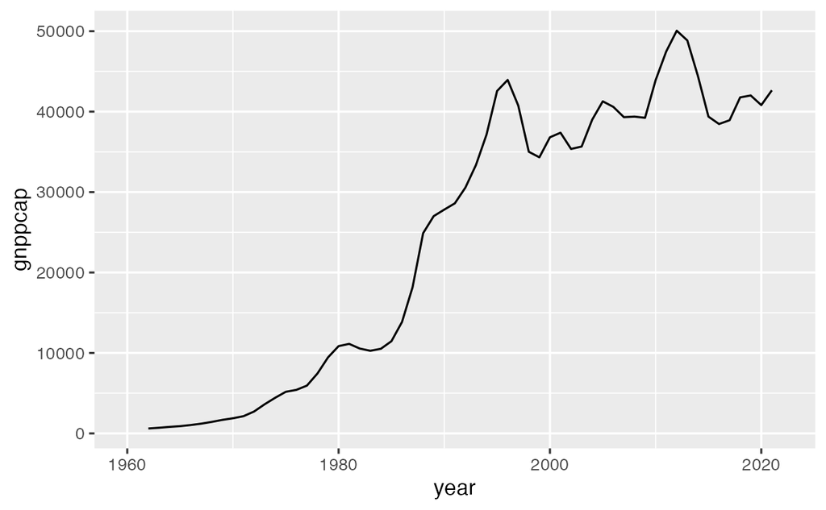

```r
df_gnppcap %>% filter(country == "Japan") %>%
  ggplot(aes(x = year, y = gnppcap)) + geom_line()
```

#### 2.3.1.1 特定の国の GNI per Capita の経年変化 について

*気づいたこと、わかったこと、疑問にわかったこと（幾つでも）*

### 2.3.2 各年ごとのデータの数

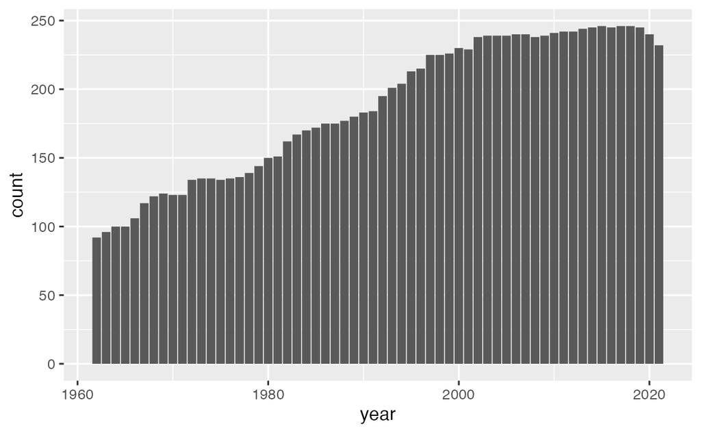

```r
df_gnppcap %>% drop_na(gnppcap) %>% ggplot(aes(x = year)) + geom_bar()
```

### 2.3.3 特定の年の GNI per Capita の降順または昇順での表示

*GDP ではなく、GNP per Capita ですから、降順 `arrange(desc(gnppcap))`、昇順`arrange(gnppcap)`、地域ごとなど、調べてみてください。下の二つのコードは何が違うかわかりますか。違っているのは、１箇所だけですね。`!=`* は否定です。

```r
df_gnppcap %>% filter(year == 2021, region != "Aggregates") %>%
  drop_na(gnppcap) %>% arrange(desc(gnppcap))
```

| country | iso2c | iso3c | year | gnppcap | status | lastupdated | region | capital | longitude | latitude | income | lending |
| --- | --- | --- | --- | --- | --- | --- | --- | --- | --- | --- | --- | --- |
| Bermuda | BM | BMU | 2021 | 122470 |  | 2023-05-10 | North America | Hamilton | -64.706 | 32.3293 | High income | Not classified |
| Switzerland | CH | CHE | 2021 | 90600 |  | 2023-05-10 | Europe & Central Asia | Bern | 7.44821 | 46.948 | High income | Not classified |
| Luxembourg | LU | LUX | 2021 | 88190 |  | 2023-05-10 | Europe & Central Asia | Luxembourg | 6.1296 | 49.61 | High income | Not classified |
| Norway | NO | NOR | 2021 | 83880 |  | 2023-05-10 | Europe & Central Asia | Oslo | 10.7387 | 59.9138 | High income | Not classified |
| Ireland | IE | IRL | 2021 | 76110 |  | 2023-05-10 | Europe & Central Asia | Dublin | -6.26749 | 53.3441 | High income | Not classified |
| United States | US | USA | 2021 | 70930 |  | 2023-05-10 | North America | Washington D.C. | -77.032 | 38.8895 | High income | Not classified |
| Denmark | DK | DNK | 2021 | 68300 |  | 2023-05-10 | Europe & Central Asia | Copenhagen | 12.5681 | 55.6763 | High income | Not classified |
| Singapore | SG | SGP | 2021 | 64010 |  | 2023-05-10 | East Asia & Pacific | Singapore | 103.85 | 1.28941 | High income | Not classified |
| Iceland | IS | ISL | 2021 | 63460 |  | 2023-05-10 | Europe & Central Asia | Reykjavik | -21.8952 | 64.1353 | High income | Not classified |
| Qatar | QA | QAT | 2021 | 62310 |  | 2023-05-10 | Middle East & North Africa | Doha | 51.5082 | 25.2948 | High income | Not classified |

[output cut: 175 more lines]

```r
df_gnppcap %>% filter(year == 2021, region == "Aggregates") %>%
  drop_na(gnppcap) %>% arrange(gnppcap)
```

| country | iso2c | iso3c | year | gnppcap | status | lastupdated | region | capital | longitude | latitude | income | lending |
| --- | --- | --- | --- | --- | --- | --- | --- | --- | --- | --- | --- | --- |
| Heavily indebted poor countries (HIPC) | XE | HPC | 2021 | 989.0512 |  | 2023-05-10 | Aggregates |  |  |  | Aggregates | Aggregates |
| Least developed countries: UN classification | XL | LDC | 2021 | 1151.2454 |  | 2023-05-10 | Aggregates |  |  |  | Aggregates | Aggregates |
| IDA only | XI | IDX | 2021 | 1275.2277 |  | 2023-05-10 | Aggregates |  |  |  | Aggregates | Aggregates |
| Pre-demographic dividend | V1 | PRE | 2021 | 1374.7778 |  | 2023-05-10 | Aggregates |  |  |  | Aggregates | Aggregates |
| IDA total | XG | IDA | 2021 | 1451.4186 |  | 2023-05-10 | Aggregates |  |  |  | Aggregates | Aggregates |
| Africa Eastern and Southern | ZH | AFE | 2021 | 1464.7940 |  | 2023-05-10 | Aggregates |  |  |  | Aggregates | Aggregates |
| Sub-Saharan Africa (excluding high income) | ZF | SSA | 2021 | 1561.4013 |  | 2023-05-10 | Aggregates |  |  |  | Aggregates | Aggregates |
| Sub-Saharan Africa (IDA & IBRD countries) | T6 | TSS | 2021 | 1562.4924 |  | 2023-05-10 | Aggregates |  |  |  | Aggregates | Aggregates |
| Africa Western and Central | ZI | AFW | 2021 | 1707.3940 |  | 2023-05-10 | Aggregates |  |  |  | Aggregates | Aggregates |
| Fragile and conflict affected situations | F1 | FCS | 2021 | 1771.2938 |  | 2023-05-10 | Aggregates |  |  |  | Aggregates | Aggregates |

[output cut: 30 more lines]

#### 2.3.3.1 特定の年の GNI per Capita の降順または昇順

*気づいたこと、わかったこと、疑問にわかったこと（幾つでも）*

### 2.3.4 いくつかの国、またはグループの GNI per Capita の経年変化

*iso2c の右の国のコードを入れ替えてみてください。*

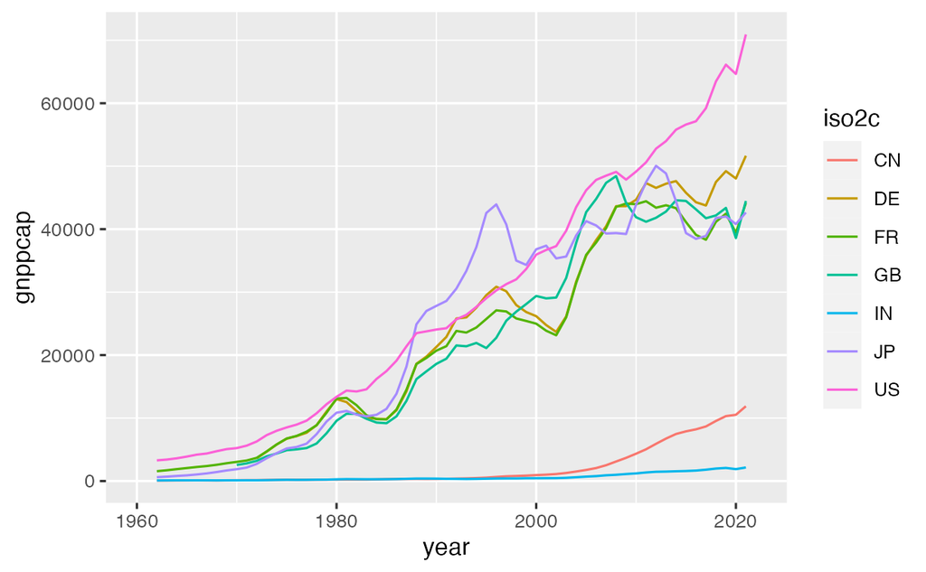

```r
df_gnppcap %>% filter(iso2c %in% c("US", "CN", "JP", "DE", "IN", "GB", "FR")) %>%
  ggplot(aes(x = year, y = gnppcap, col = iso2c)) + geom_line()
```

*下はどんな地域でしょうか。調べたい国や地域の iso2c を入れてください。*

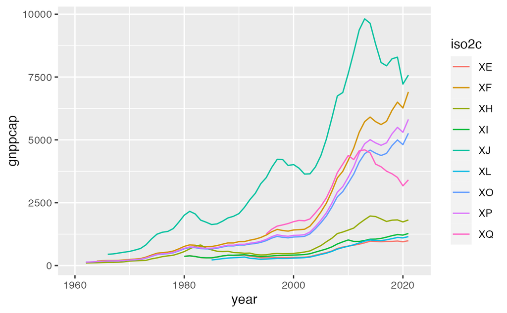

```r
df_gnppcap %>% filter(iso2c %in% c("XE", "XL", "XI", "XH","XQ","XO", "XP", "XF", "XJ")) %>%
  ggplot(aes(x = year, y = gnppcap, col = iso2c)) + geom_line()
```

#### 2.3.4.1 いくつかの国、またはグループの GNI per Capita の経年変化

*気づいたこと、わかったこと、疑問にわかったこと（幾つでも）*

### 2.3.5 グループごとの国の数

*世界のGDP における割合に変えて、それぞれのグループに属する国の数を見てみましょう。*

*income level は、毎年変更しているわけではないので、現在の income level の国について、データがあるかという数です。人口とかがわかると面白いかもしれませんね。*

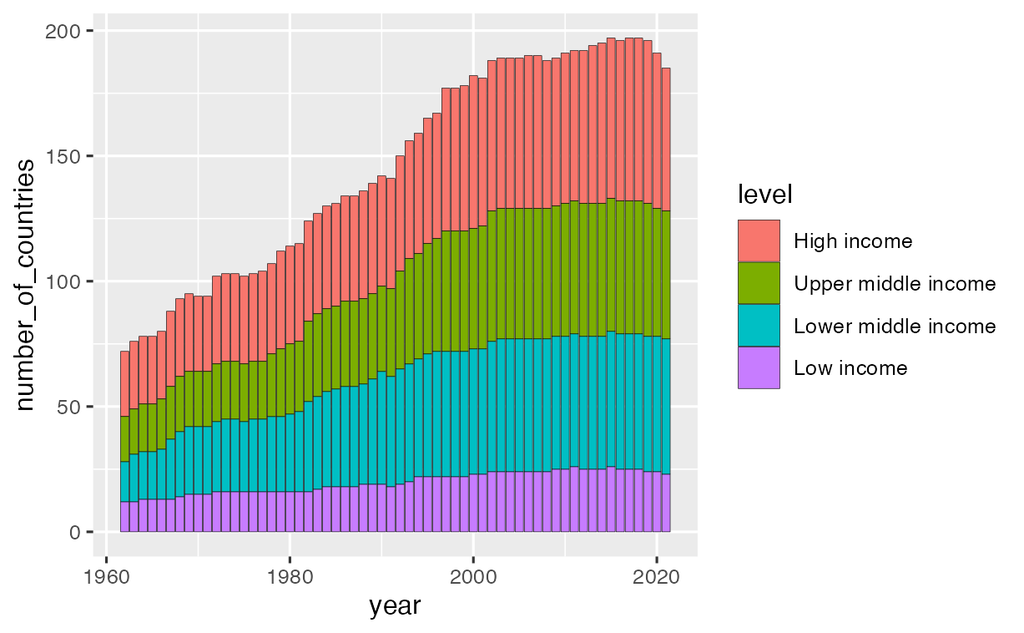

```r
df_gnppcap %>% drop_na(gnppcap) %>% filter(region != "Aggregates") %>%
  filter(income != "Not classified") %>%
  group_by(year, income) %>% summarize(number_of_countries = n()) %>%
  mutate(level = factor(income, c("High income", "Upper middle income", "Lower middle income", "Low income"))) %>%
  ggplot(aes(x = year, y = number_of_countries, fill = level)) +
  geom_col(col = "black", linewidth = 0.1)
```

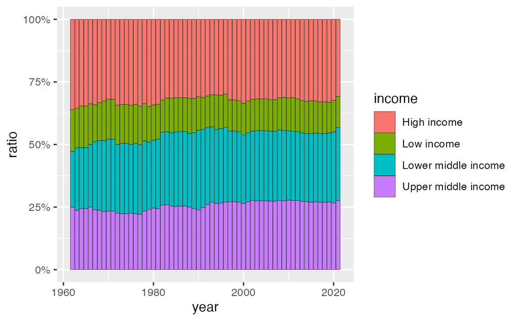

```r
df_gnppcap %>% drop_na(gnppcap) %>% filter(region != "Aggregates") %>%
  filter(income != "Not classified") %>%
  group_by(year, income) %>% summarize(number_of_countries = n()) %>%
  mutate(ratio = number_of_countries/sum(number_of_countries)) %>%
  mutate(level = factor(income, c("High income", "Upper middle income", "Lower middle income", "Low income"))) %>%
  ggplot(aes(x = year, y = ratio, fill = income)) +
  geom_col(col = "black", linewidth = 0.1)  +
  scale_y_continuous(labels = scales::percent_format(accuracy = 1))
```

### 2.3.6 特定の年の世界の国の GNI per Capita の分布

*年を変更したり、幅を変更したり、分ける個数を変更するなど。 `binwidth = 0.5` や、`bins = 20` を、`geom_histogram()` のかっこの中に入れます。*

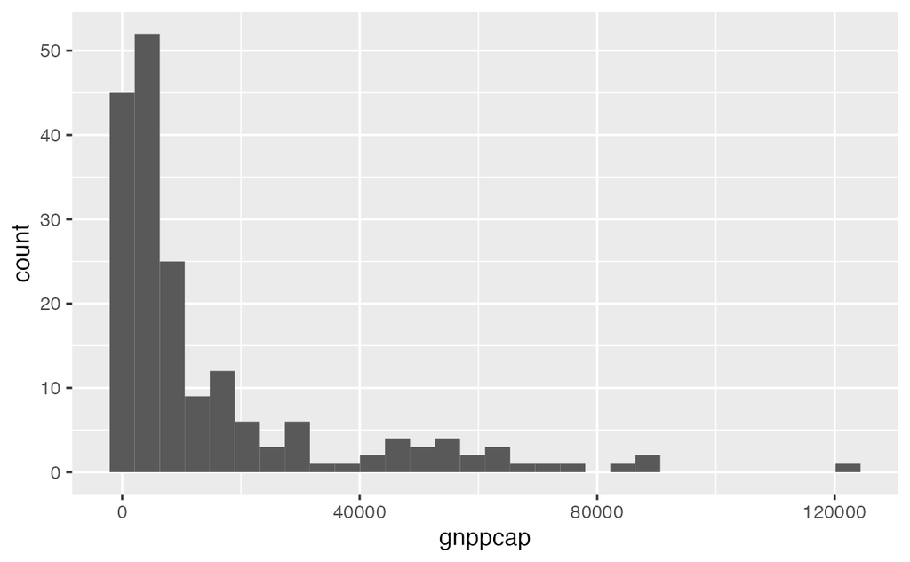

```r
df_gnppcap %>% drop_na(gnppcap) %>%
  filter(year == 2021) %>% filter(region  != "Aggregates") %>%
  ggplot(aes(gnppcap)) + geom_histogram()
```

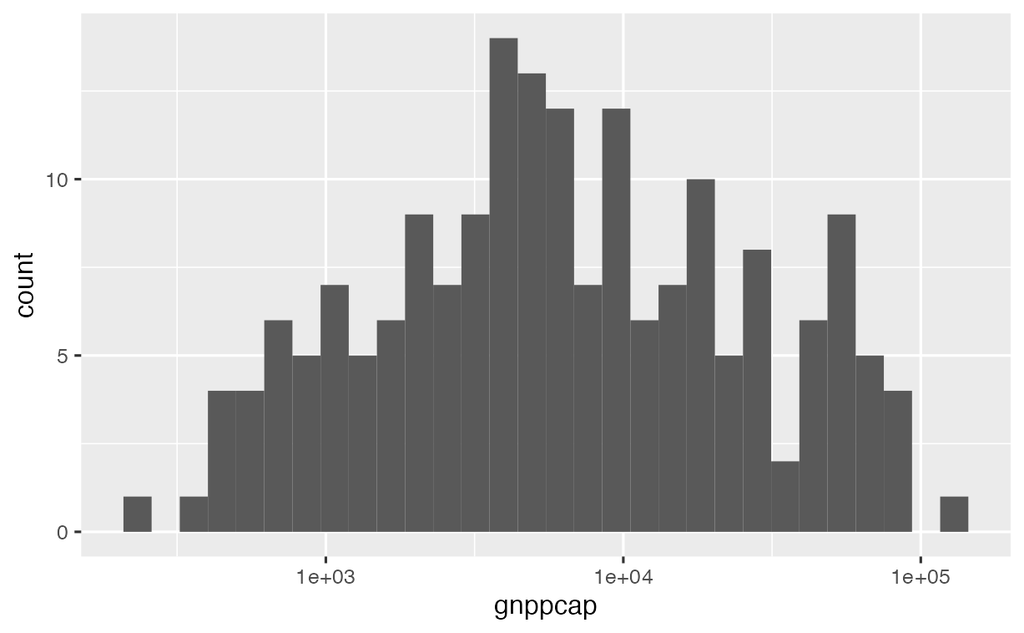

```r
df_gnppcap %>% drop_na(gnppcap) %>%
  filter(year == 2021) %>% filter(region  != "Aggregates") %>%
  ggplot(aes(gnppcap)) + geom_histogram() + scale_x_log10()
```

また、密度曲線に変えるには、`geom_density` を使います。

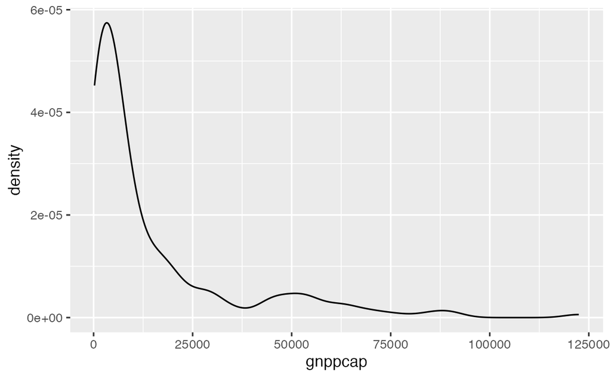

```r
df_gnppcap %>% drop_na(gnppcap) %>%
  filter(year == 2021) %>% filter(region  != "Aggregates") %>%
  ggplot(aes(gnppcap)) + geom_density()
```

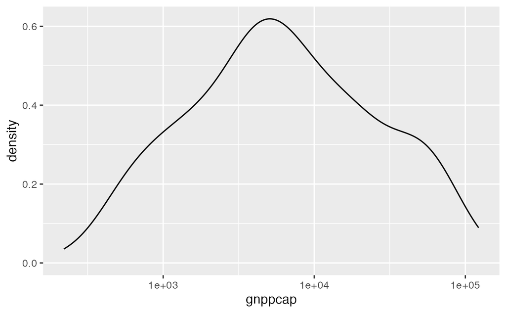

```r
df_gnppcap %>% drop_na(gnppcap) %>%
  filter(year == 2021) %>% filter(region  != "Aggregates") %>%
  ggplot(aes(gnppcap)) + geom_density() + scale_x_log10()
```

*これは、2021年のデータですが、density の変化を見てみます。alpha の値は透明度です。*

*log10 scale と log10 をつけないものと、どちらがみやすいですか。*

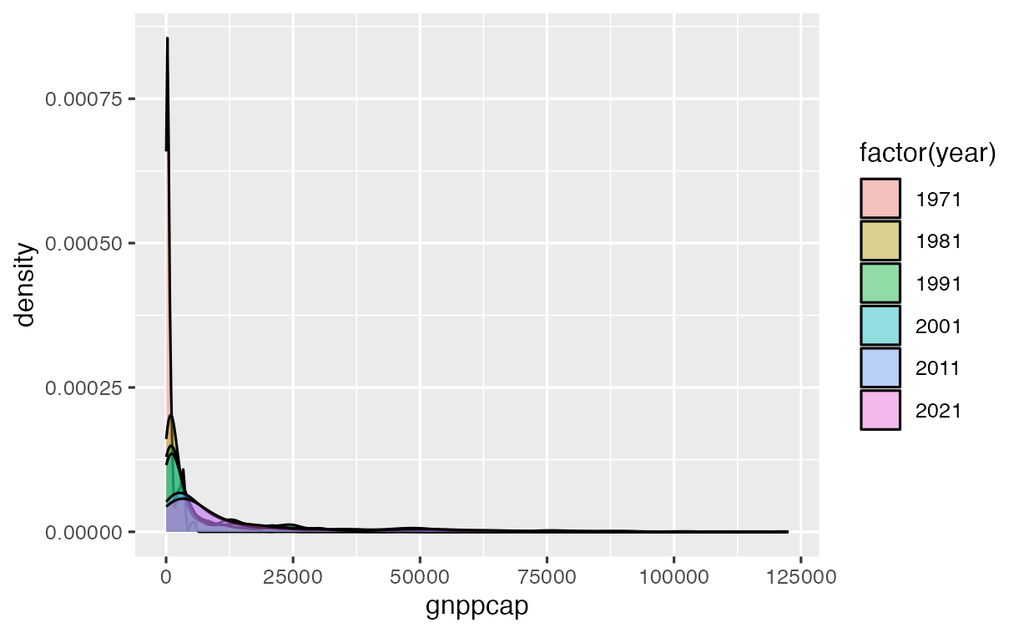

```r
df_gnppcap %>% drop_na(gnppcap) %>% filter(region  != "Aggregates") %>%
  filter(year %in% c(1961, 1971, 1981, 1991, 2001, 2011, 2021)) %>%
  ggplot(aes(gnppcap, fill = factor(year))) + geom_density(alpha = 0.4)
```

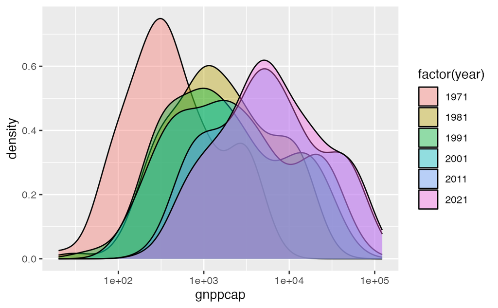

```r
df_gnppcap %>% drop_na(gnppcap) %>% filter(region  != "Aggregates") %>%
  filter(year %in% c(1961, 1971, 1981, 1991, 2001, 2011, 2021)) %>%
  ggplot(aes(gnppcap, fill = factor(year))) + geom_density(alpha = 0.4) + scale_x_log10()
```

少しみにくいので、分けてみます。

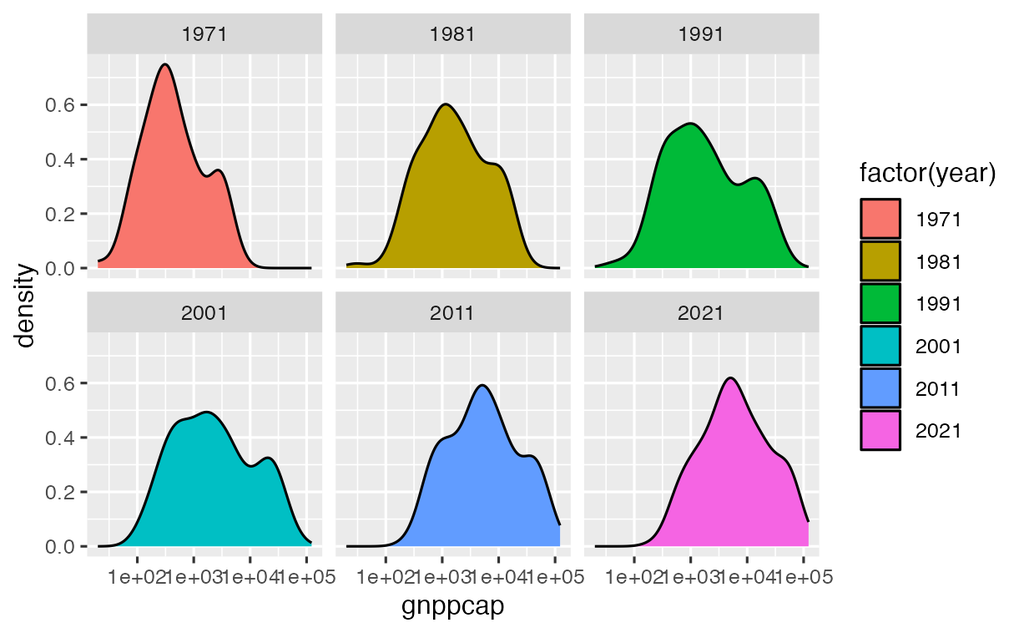

```r
df_gnppcap %>% drop_na(gnppcap) %>% filter(region  != "Aggregates") %>%
  filter(year %in% c(1971, 1981, 1991, 2001, 2011, 2021)) %>%
  ggplot(aes(gnppcap, fill = factor(year))) +
  geom_density() + scale_x_log10() + facet_wrap(~year)
```

#### 2.3.6.1 特定の年の GNI per Capita の分布について

*気づいたこと、わかったこと、疑問にわかったこと（幾つでも）*

### 2.3.7 グループごとの GNI per Capita の分布

*いくつかのグループごとに分布をみてみることも可能です。それには、Boxplot が有効です*。

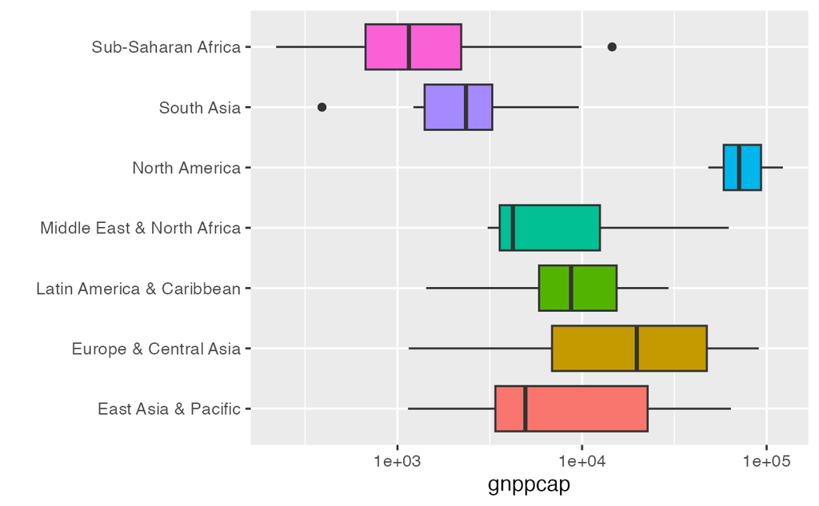

```r
df_gnppcap %>% drop_na(gnppcap) %>% filter(region != "Aggregates") %>%
  drop_na(region) %>% filter(year %in% c(2021)) %>%
  ggplot(aes(gnppcap, region, fill = region)) +
  geom_boxplot() + scale_x_log10() + labs(y = "") +
  theme(legend.position = "none")
```

*収入の多寡による分類ごとの GNI per Capita の分布*

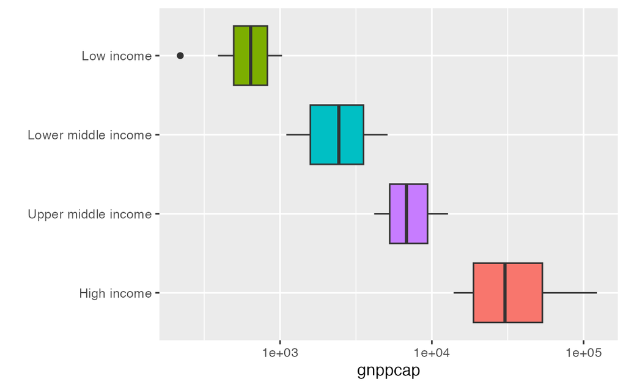

```r
df_gnppcap %>% drop_na(gnppcap) %>% filter(region != "Aggregates") %>%
  drop_na(income) %>% filter(year %in% c(2021)) %>%
  mutate(level = factor(income, c("High income", "Upper middle income", "Lower middle income", "Low income"))) %>%
  ggplot(aes(gnppcap, level, fill = income)) +
  geom_boxplot() + scale_x_log10() + labs(y = "") +
  theme(legend.position = "none")
```

### 2.3.8 グループごとの GNI per Capita の分布について

*気づいたこと、わかったこと、疑問にわかったこと（幾つでも）*

### 2.3.9 色分け地図

*世界地図の準備*

```r
library(maps)
gnppcap_short <- df_gnppcap %>% filter(year == 2021, region != "Aggregates") %>%
  select(iso2c, gnppcap, income)
map_world <- map_data('world')
map_gnppcap <- map_world %>%
  mutate(iso2c = iso.alpha(region, n=2)) %>%
  left_join(gnppcap_short, by = "iso2c")
head(map_gnppcap)
```

|  | long | lat | group | order | region | subregion | iso2c | gnppcap | income |
| --- | --- | --- | --- | --- | --- | --- | --- | --- | --- |
| 1 | -69.89912 | 12.45200 | 1 | 1 | Aruba | NA | AW | 29390 | High income |
| 2 | -69.89571 | 12.42300 | 1 | 2 | Aruba | NA | AW | 29390 | High income |
| 3 | -69.94219 | 12.43853 | 1 | 3 | Aruba | NA | AW | 29390 | High income |
| 4 | -70.00415 | 12.50049 | 1 | 4 | Aruba | NA | AW | 29390 | High income |
| 5 | -70.06612 | 12.54697 | 1 | 5 | Aruba | NA | AW | 29390 | High income |
| 6 | -70.05088 | 12.59707 | 1 | 6 | Aruba | NA | AW | 29390 | High income |

*Income Level による色分け地図*

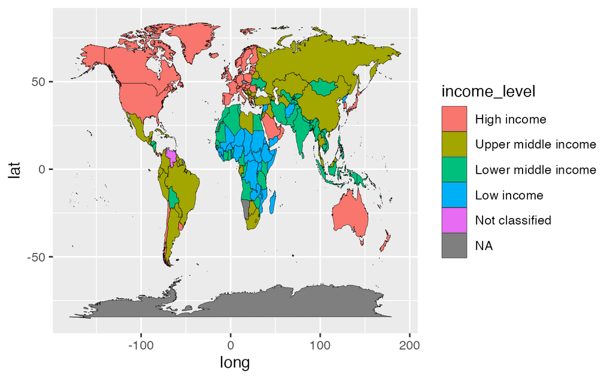

```r
map_gnppcap %>% mutate(income_level = factor(income, levels = c("High income", "Upper middle income", "Lower middle income", "Low income", "Not classified", NA))) %>%
  ggplot() +
  geom_map(aes(long, lat, map_id = region, fill = income_level), map = map_world, col = "black", size = 0.1)
```

*GNI per Capita による色分け地図*

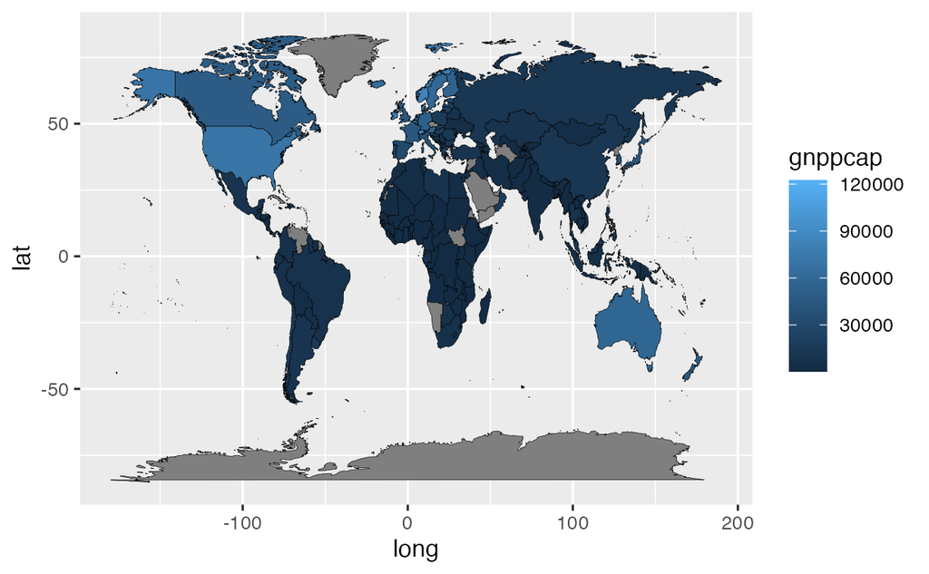

```r
map_gnppcap %>%
  ggplot() +
  geom_map(aes(x=long, y=lat, map_id = region, fill = gnppcap), map = map_world, col = "black", size = 0.1)
```

### 2.3.10 色分け地図 について

*気づいたこと、わかったこと、疑問にわかったこと（幾つでも）*

# 3 プロジェクト2

## 3.1 データ取得

## 3.2 データ構造の確認

## 3.3 様々な視覚化によるデータ理解

*気づいたこと、わかったこと、疑問にわかったことの記述をお忘れなく。*

# 4 プロジェクト3

## 4.1 調べたWDI の名称と、データコード

*WDI name と data code を最初に書いておいてください。*